# ESA 2019 Family planning and fertility III

2019-08-21

## *Heterogeneous treatment effects of early parenthood on later life mental health*

**Sara Kalucza**,  
University of Queensland | Umeå University

**Martin O'Flaherty**,  
University of Queensland

**Joshua Bon**,  
University of Queensland | Queensland University of Technology

## Background

- Detrimental effects of young parenthood: What do we know?
  - Many of the large detrimental effects identified in earlier litterature has been questioned and disproven
  - Persistent small effects on later life outcomes
  - Focus has largely been on educational and labour market outcomes, not as much on wellbeing and health
- What is hiding behind average effects?
  - There has been some previous investigation,  
    eg, Xie, Brand & Jann (2012), Diaz & Fiel (2016)

## Measuring heterogeneous treatment effects with BART

- Bayesian Additative Regression Trees
- Combines Bayesian tree models with the use of backfitting via MCMC
- BART developed by Chipman, George & McCulloch (2010), and extended as a causal inference tool by Hill (2011)
- Implementation via bartMachine (2016), supported by the purpose built tidytreatment package

## How it works - Tree based models

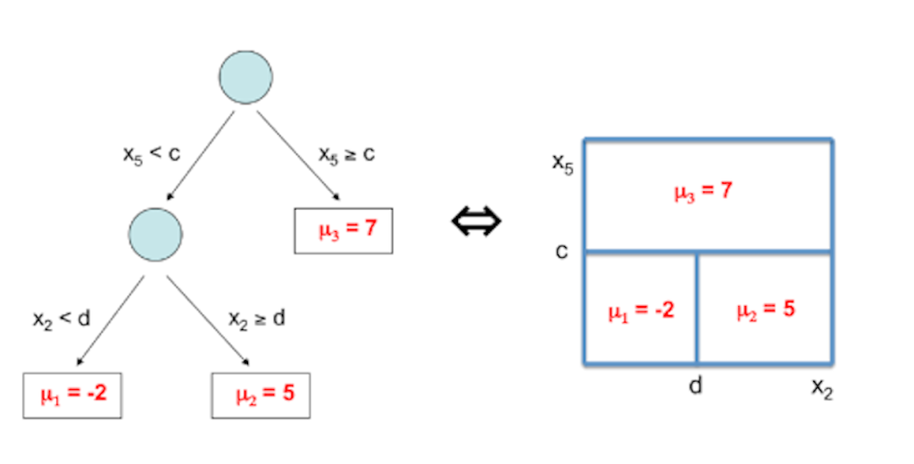

*Source: https://www.asc.ohio-state.edu/statistics/comp_exp/jour.club/trees.pdf*

- Explains a little bit of the covariate space at the time
- Finds the best binary splits, with a coefficient for each terminal node

```
                Many small trees > One large and complex tree
```

[figure not shown]

## Why BART

- Through the use of priors the model balances complexity in data and a simple fit = avoids overfitting,
  - Provides an ready to use set of default priors that have been shown to be robust.
- Naturally handles interaction and nonlinearity, because of its tree structure
- Avoids multiple comparison bias issues that arise with many interaction effects

[figure not shown]

- Large amount of covariates makes the *unconfoundedness assumption* more plausible: makes BART useful for average effects too
- Efficient in modelling *heterogeneity*: can be modelled in several ways, such as incorporating propensity scores

## Our Study

*Our aim is to estimate the effect of young parenthood on later life mental health, with special attention to heterogenous treatment effects.*

**Data:**

*The 1970 British Cohort Study (BCS70)* following the lives of children born during one week in Scotland & Wales. Including 148 covariates spanning 14 domains such as

```
- Education and aspirations

- Socio-economic background

- Adolescent mental and physical health

- Social Support, peers etc
```

## Implementation

**R Packages:** *bartMachine*, *tidytreatment*

**tidytreatment details:**

- calculates *tidy* posterior summaries for Bayesian causal models in R.
- Interfaces nicely with other packages in the tidyverse (e.g. ggplot2).

**MCMC details**

- 40,000 iterations (+ 10,000 burnin)
- 200 trees in each iteration

## Results

[figure not shown]

## Variable inclusion top

Propensity score, 99%

Becoming a young parent, 83%

1. Parental aspiration: Age *Individuals* Mother thinks *Individual* is going to leave school (age 10) (aspirations), 79%
2. SES background: Maternal Grandfather Social Class (age 10), 77%
3. SES background: Mothers year of schooling (age 5), 77%
4. Material affluence: Interviewer description home - luxuriousness (age 5), 69%
5. Mental health: I think I am the wrong weight (age 16), 68%

## Individual conditional treatment effects

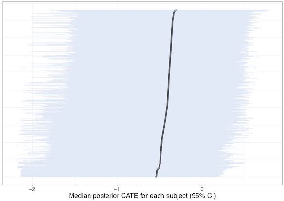

## Individual conditional treatment effects

[figure not shown]

## Preliminary conclusions

**Substantive topic**

- There is a (very small) negative effect, is it substantially important?
- What is hiding behind the average effect? A consistently stable effect
- Limitation: Missingness in the age 16 covariates.

**Implementing BART**

- We are very positive about the potentials of BART
- The model handeled large amounts of missingness well
- We see promises for BART for both average effects and heterogeneity in effects

## Thank You for Listening!

Sara Kalucza, University of Queensland | Umeå University  
s.kalucza@uq.edu.au

Martin O'Flaherty, University of Queensland

Joshua Bon, Queensland University of Technology | University of Queensland

*This presentation is available at* https://skalucza.github.io/ESApresentation/

## References

Chipman HA, George EI, McCulloch RE (2010). BART: Bayesian additive regression trees. The Annals of Applied Statistics. 1(4): 266–298

Diaz, C. J., & Fiel, J. E. (2016). The Effect(s) of Teen Pregnancy: Reconciling Theory, Methods, and Findings. Demography, 53(1), 85–116.

Hill JL. (2011) Bayesian nonparametric modeling for causal inference. Journal of Computational and Graphical Statistics. 1(20): 217–240.

Xie, Y., Brand, J. E., & Jann, B. (2012). Estimating Heterogeneous Treatment Effects with Observational Data. Sociological Methodology, 42(1), 314–347.

Kapelner, A., & Bleich, J. (2016). bartMachine: Machine Learning with Bayesian Additive Regression Trees. Journal of Statistical Software, 70(4). https://doi.org/10.18637/jss.v070.i04

**tidybayes package**: GitHub.com/bonstats/tidytreatment